# Прогнозирование оттока клиентов банка

Клиентами банка являются физические и юридические лица, которые заключили договор с банком и пользуются услугами и продуктами, предоставляемыми банком. Явление, когда клиенты перестают пользоваться продуктами и услугами банка и прекращают любые юридически оформленные отношения с банком, называется оттоком.

Отток клиентов может возникать по разным причинам. Клиенты начинают уходить, если не удовлетворены качеством и видом банковских продуктов и услуг, их стоимостью, удобством использования, качеством предоставляемого сервиса; если теряется актуальность продуктов и услуг; если изменяется экономическая ситуация в семье, стране. Кроме того, отток может свидетельствовать о снижении конкурентной способности банка, если уход клиента связан с переходом в другой банк.

Прибыль банка напрямую зависит от количества обслуживаемых клиентов. Поэтому отток клиентов прежде всего сказывается на финансовых показателях банка: снижается количество клиентов — уменьшается ресурсная база банковской системы — уменьшается число вкладов и кредитов. Это приводит к снижению доходности и упущенным финансовым возможностям.

Отток клиентов из банка становится заметным, когда количество клиентов, которые перестают пользоваться услугами банка, превышает ожидаемый уровень. Ежемесячное отслеживание оттока помогает банку определить, какие клиенты уходят, и помогает изучить причины, по которым уходят клиенты.

Кроме того, отслеживание оттока клиентов помогает банку оценить эффективность своих маркетинговых усилий и стратегий удержания клиентов. Если банк знает, какие клиенты покидают его наиболее часто, он может сосредоточиться на улучшении своих маркетинговых кампаний и программ лояльности, чтобы удержать этих клиентов. Наконец, отслеживание ежемесячного оттока помогает банку оценивать свою конкурентоспособность на рынке.

Отток клиентов является одним из показателей качества работы банка. Понимание этого показателя помогает банку оценить свою работу, принять меры для улучшения качества обслуживания и сделать его более привлекательным для тех, кто уже является клиентом банка.

Поэтому банкам важно понимать причины ухода клиентов и принимать меры для его предотвращения или уменьшения. Если банк регулярно производит анализ оттока клиентов, то он может быстро реагировать на возникающие проблемы: внедрять новые продукты и услуги и улучшать своё обслуживание, чтобы удержать клиентов и привлечь новых.

Для банка сохранение текущих клиентов позволяет увеличить свои доходы и укрепить репутацию надёжного банка. Привлечение новых клиентов может стать для банка очень дорогостоящим и времязатратным процессом.

Текущие клиенты обычно пользуются несколькими услугами банка. Они уже знакомы с банком и установили с ним отношения доверия: их предпочтения, нужды и ожидания банку известны. Текущие клиенты могут порекомендовать банк своим друзьям и знакомым, что приведёт к привлечению новых клиентов без дополнительных затрат на маркетинг со стороны банка.

Для улучшения качества обслуживания клиентов и увеличения прибыли банка необходимо прогнозировать отток клиентов из банка. Для построения прогноза необходимо иметь данные о поведении клиентов.

В нашем распоряжении находятся данные о поведении клиентов банка — клиентов, которые продолжают обслуживаться в банке и которые уже ушли. Для каждого клиента доступны персональные данные (фамилия, пол, возраст, регион проживания, уровень дохода) и поведенческие данные — данные об активности клиентов (наличие продуктов, предлагаемых банком, кредитный рейтинг, период обслуживания в банке, текущий баланс счёта).

Для того чтобы определить, уйдёт ли клиент из банка или останется, нужно построить модель, которая сможет проанализировать персональные и поведенческие данные клиентов и наиболее точным образом спрогнозирует потенциальный уход клиента.

**Цель проекта:** построить модель, прогнозирующую отток клиентов банка.

**Задачи проекта:**

- выполнить предобработку данных (при необходимости);
- провести описательный анализ данных;
- разбить данные на тренировочную и валидационную выборки (при необходимости выделить тестовую выборку);
- выбрать алгоритмы и построить модели;
- учесть дисбаланс классов (при необходимости);
- выбрать метрики качества моделей и оценить их значения.

# Содержание

## Обзор данных

### Импорт библиотек и предварительные настройки

```python
import pandas as pd
import matplotlib.pyplot as plt
import numpy as np
import seaborn as sns
import sys
import os
import re

from sklearn.model_selection import train_test_split
from sklearn.utils import shuffle
from sklearn.preprocessing import StandardScaler
from sklearn.tree import DecisionTreeClassifier
from sklearn.ensemble import RandomForestClassifier
from sklearn.linear_model import LogisticRegression
from sklearn.metrics import (accuracy_score, precision_score, recall_score,
                             f1_score, roc_auc_score)

pd.set_option('display.max_columns', None)
np.set_printoptions(threshold=sys.maxsize)

RANDOM_STATE = 1
```

### Чтение файла и загрузка данных

Все данные хранятся в одном файле.  
Файл данных `Churn.csv` имеет формат `CSV`.

```python
pth1 = r'C:\Users\Георгий\Documents\DS_projects\Churn.csv'
pth2 = '/datasets/Churn.csv'
pth3 = '/content/Churn.csv'

if os.path.exists(pth1):
    data = pd.read_csv(pth1)
elif os.path.exists(pth2):
    data = pd.read_csv(pth2)
elif os.path.exists(pth3):
    data = pd.read_csv(pth3)
else:
    print('Something is wrong')
```

Убедимся, что данные подгрузились верно, без ошибок.

Для этого выведем первые 10 строк и последние 10 строк набора данных.

```python
data.head(10)
```

|  | RowNumber | CustomerId | Surname | CreditScore | Geography | Gender | Age | Tenure | Balance | NumOfProducts | HasCrCard | IsActiveMember | EstimatedSalary | Exited |
| --- | --- | --- | --- | --- | --- | --- | --- | --- | --- | --- | --- | --- | --- | --- |
| 0 | 1 | 15634602 | Hargrave | 619 | France | Female | 42 | 2.0 | 0.00 | 1 | 1 | 1 | 101348.88 | 1 |
| 1 | 2 | 15647311 | Hill | 608 | Spain | Female | 41 | 1.0 | 83807.86 | 1 | 0 | 1 | 112542.58 | 0 |
| 2 | 3 | 15619304 | Onio | 502 | France | Female | 42 | 8.0 | 159660.80 | 3 | 1 | 0 | 113931.57 | 1 |
| 3 | 4 | 15701354 | Boni | 699 | France | Female | 39 | 1.0 | 0.00 | 2 | 0 | 0 | 93826.63 | 0 |
| 4 | 5 | 15737888 | Mitchell | 850 | Spain | Female | 43 | 2.0 | 125510.82 | 1 | 1 | 1 | 79084.10 | 0 |
| 5 | 6 | 15574012 | Chu | 645 | Spain | Male | 44 | 8.0 | 113755.78 | 2 | 1 | 0 | 149756.71 | 1 |
| 6 | 7 | 15592531 | Bartlett | 822 | France | Male | 50 | 7.0 | 0.00 | 2 | 1 | 1 | 10062.80 | 0 |
| 7 | 8 | 15656148 | Obinna | 376 | Germany | Female | 29 | 4.0 | 115046.74 | 4 | 1 | 0 | 119346.88 | 1 |
| 8 | 9 | 15792365 | He | 501 | France | Male | 44 | 4.0 | 142051.07 | 2 | 0 | 1 | 74940.50 | 0 |
| 9 | 10 | 15592389 | H? | 684 | France | Male | 27 | 2.0 | 134603.88 | 1 | 1 | 1 | 71725.73 | 0 |

```python
data.tail(10)
```

|  | RowNumber | CustomerId | Surname | CreditScore | Geography | Gender | Age | Tenure | Balance | NumOfProducts | HasCrCard | IsActiveMember | EstimatedSalary | Exited |
| --- | --- | --- | --- | --- | --- | --- | --- | --- | --- | --- | --- | --- | --- | --- |
| 9990 | 9991 | 15798964 | Nkemakonam | 714 | Germany | Male | 33 | 3.0 | 35016.60 | 1 | 1 | 0 | 53667.08 | 0 |
| 9991 | 9992 | 15769959 | Ajuluchukwu | 597 | France | Female | 53 | 4.0 | 88381.21 | 1 | 1 | 0 | 69384.71 | 1 |
| 9992 | 9993 | 15657105 | Chukwualuka | 726 | Spain | Male | 36 | 2.0 | 0.00 | 1 | 1 | 0 | 195192.40 | 0 |
| 9993 | 9994 | 15569266 | Rahman | 644 | France | Male | 28 | 7.0 | 155060.41 | 1 | 1 | 0 | 29179.52 | 0 |
| 9994 | 9995 | 15719294 | Wood | 800 | France | Female | 29 | 2.0 | 0.00 | 2 | 0 | 0 | 167773.55 | 0 |
| 9995 | 9996 | 15606229 | Obijiaku | 771 | France | Male | 39 | 5.0 | 0.00 | 2 | 1 | 0 | 96270.64 | 0 |
| 9996 | 9997 | 15569892 | Johnstone | 516 | France | Male | 35 | 10.0 | 57369.61 | 1 | 1 | 1 | 101699.77 | 0 |
| 9997 | 9998 | 15584532 | Liu | 709 | France | Female | 36 | 7.0 | 0.00 | 1 | 0 | 1 | 42085.58 | 1 |
| 9998 | 9999 | 15682355 | Sabbatini | 772 | Germany | Male | 42 | 3.0 | 75075.31 | 2 | 1 | 0 | 92888.52 | 1 |
| 9999 | 10000 | 15628319 | Walker | 792 | France | Female | 28 | NaN | 130142.79 | 1 | 1 | 0 | 38190.78 | 0 |

### Общая характеристика набора данных

Размер набора данных:

```python
data.shape
```

```
(10000, 14)
```

Количество дубликатов в наименованиях признаков:

```python
data.columns.duplicated().sum()
```

```
0
```

Уникальные наименования признаков:

```python
data.columns.sort_values().tolist()
```

```
['Age',
 'Balance',
 'CreditScore',
 'CustomerId',
 'EstimatedSalary',
 'Exited',
 'Gender',
 'Geography',
 'HasCrCard',
 'IsActiveMember',
 'NumOfProducts',
 'RowNumber',
 'Surname',
 'Tenure']
```

Количество элементов данных:

```python
data.size
```

```
140000
```

Типы данных набора данных:

```python
data.dtypes.value_counts()
```

```
int64      8
object     3
float64    3
dtype: int64
```

Пропущенные значения в данных:

```python
data.isna().sum()
```

```
RowNumber            0
CustomerId           0
Surname              0
CreditScore          0
Geography            0
Gender               0
Age                  0
Tenure             909
Balance              0
NumOfProducts        0
HasCrCard            0
IsActiveMember       0
EstimatedSalary      0
Exited               0
dtype: int64
```

Распределение пропущенных значений в наборе данных:

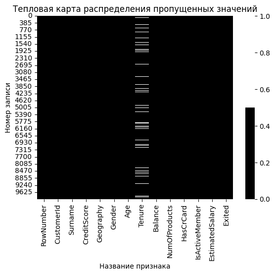

```python
sns.heatmap(data.isna(), cmap=sns.color_palette(['#000000', '#ffffff']))
plt.title('Тепловая карта распределения пропущенных значений')
plt.xlabel('Название признака')
plt.ylabel('Номер записи')
plt.show()
```

**Промежуточный вывод**

- Набор данных содержит 14 уникальных признаков и 10 000 записей.
- Всего: 140 000 элементов данных.
- Набор данных содержит данные следующего типа:
  - целочисленный — 8 признаков,
  - вещественный — 3 признака,
  - смешанного типа — 3 признака.
- Все признаки содержат значения (не являются пустыми).
- 13 признаков не содержат пропущенные значения.
- 1 признак содержит пропущенные значения:
  - распределение пропусков в данных не носит регулярный характер,
  - всего в данных 909 пропущенных значений — около 0,6 % от всех элементов данных.
- Необходимо привести названия признаков к "змеиному_регистру".

### Преобразование наименований признаков

Приведение названий столбцов к "змеиному_регистру".

```python
data = data.rename(
    columns=lambda column: re.sub(r'(?<!^)(?=[A-Z])', '_', column).lower())
data.columns.tolist()
```

```
['row_number',
 'customer_id',
 'surname',
 'credit_score',
 'geography',
 'gender',
 'age',
 'tenure',
 'balance',
 'num_of_products',
 'has_cr_card',
 'is_active_member',
 'estimated_salary',
 'exited']
```

```python
data.head()
```

|  | row_number | customer_id | surname | credit_score | geography | gender | age | tenure | balance | num_of_products | has_cr_card | is_active_member | estimated_salary | exited |
| --- | --- | --- | --- | --- | --- | --- | --- | --- | --- | --- | --- | --- | --- | --- |
| 0 | 1 | 15634602 | Hargrave | 619 | France | Female | 42 | 2.0 | 0.00 | 1 | 1 | 1 | 101348.88 | 1 |
| 1 | 2 | 15647311 | Hill | 608 | Spain | Female | 41 | 1.0 | 83807.86 | 1 | 0 | 1 | 112542.58 | 0 |
| 2 | 3 | 15619304 | Onio | 502 | France | Female | 42 | 8.0 | 159660.80 | 3 | 1 | 0 | 113931.57 | 1 |
| 3 | 4 | 15701354 | Boni | 699 | France | Female | 39 | 1.0 | 0.00 | 2 | 0 | 0 | 93826.63 | 0 |
| 4 | 5 | 15737888 | Mitchell | 850 | Spain | Female | 43 | 2.0 | 125510.82 | 1 | 1 | 1 | 79084.10 | 0 |

## Понимание данных

Все признаки в наборе данных можно разделить на три вида:

- технические данные,
- персональные данные клиента,
- данные об активности клиента.

***Технические данные***

Технические данные позволяют различать клиентов и записи о них. Одно значение соответствует одному клиенту. Значения для всех записей различны.

Все записи в наборе данных пронумерованы по порядку, начиная с 1.

`row_number` — индекс строки в данных  
Признак является категориальным, ординальным.  
Шкала измерения признака: порядковая шкала.

> **Уникальный идентификатор клиента банка** — это уникальный код или номер, который присваивается каждому клиенту банка для идентификации его в системе банка.

Идентификатор может использоваться для доступа к информации о клиенте, его счетах, кредитах и других финансовых операциях. Как правило, уникальный идентификатор представлен в виде цифр или буквенно-цифровой комбинации.

`customer_id` — уникальный идентификатор клиента  
Признак является категориальным, ординальным.  
Шкала измерения признака: порядковая шкала.

***Персональные данные клиента***

> **Персональные данные клиента** — это любая информация, которая относится к конкретному человеку и позволяет однозначно его идентифицировать.

К персональным данным относятся сведения о фамилии, имени, отчестве, поле и возрасте, местонахождении, уровне доходов.

`surname` — фамилия  
Признак является категориальным, номинальным.  
Шкала измерения признака: номинальная шкала.

`gender` — пол  
Признак является категориальным, бинарным.  
Шкала измерения признака: дихотомическая шкала.

`age` — возраст (лет)  
Признак является количественным, непрерывным.  
Шкала измерения признака: интервальная шкала.

`geography` — страна проживания  
Признак является категориальным, номинальным.  
Шкала измерения признака: номинальная шкала.

> **Предполагаемая банком зарплата клиента** — это сумма, которую банк ожидает, что клиент будет получать в качестве заработной платы в течение месяца или полугодия.

Эта информация позволяет банку определить доступную клиенту сумму кредита, а также выгодные условия кредитования. Для определения предполагаемой зарплаты банк может запросить у клиента документы, подтверждающие его доходы.

`estimated_salary` — предполагаемая зарплата (у. е.)  
Признак является количественным, непрерывным.  
Шкала измерения признака: шкала отношений.

***Данные об активности клиента***

> **Данные о поведении клиентов банка** — это информация о действиях клиентов в рамках использования банковских продуктов и услуг.

Эти данные помогают банкам понимать потребности и предпочтения своих клиентов, выявлять тенденции и механизмы, способствующие сохранению клиентской базы, а также прогнозировать поведение клиентов и предлагать более персонализированные продукты и услуги.

> **Период обслуживания в банке** — это временной интервал, в течение которого клиент может получить доступ к предоставляемым банком услугам.

`tenure` — период обслуживания в банке (лет)  
Признак является количественным, дискретным.  
Шкала измерения признака: шкала разностей.

> **Активность клиента банка** — это уровень использования банковских продуктов и услуг клиентом, оценённый банком.

Клиент, который часто пользуется кредитами, дебетовыми и кредитными картами, оформляет депозиты или инвестирует деньги, является активным клиентом. Активность клиентов также может оцениваться по частоте и объёму совершаемых операций.

`is_active_member` — факт того, является ли клиент активным  
Признак является категориальным, бинарным.  
Шкала измерения признака: дихотомическая шкала.

> **Баланс банковского счета** — это сумма денег, которая остаётся на счёте после списания всех расходов и начисления всех доходов за определённый период времени.

Баланс счёта показывает остаток средств на счёте в заданный момент времени.

`balance` — баланс банковского счёта (у. е.)  
Признак является количественным, непрерывным.  
Шкала измерения признака: шкала отношений.

> **Продукты банка** — это финансовые продукты и услуги, которые предлагаются банком клиентам для совершения различных финансовых операций.

`num_of_products` — количество продуктов банка, используемых клиентом  
Признак является количественным, дискретным.  
Шкала измерения признака: абсолютная шкала.

> **Кредитная карта** — это банковская карта, которая позволяет её владельцу распоряжаться средствами на кредитном счёте, предоставленном банком в рамках заранее одобренного кредитного лимита.

Кредитная карта позволяет клиенту оплачивать товары и услуги за счёт средств банка.

`has_cr_card` — наличие кредитной карты  
Признак является категориальным, бинарным.  
Шкала измерения признака: дихотомическая шкала.

> **Кредитный рейтинг** — это числовая оценка кредитоспособности заёмщика, которую выставляет кредитное бюро на основании анализа его кредитной истории, финансовой стабильности и рисков, связанных с возможной задолженностью.

Рейтинг может использоваться банками для принятия решения о выдаче кредита или организации финансовых отношений с конкретным заёмщиком.

`credit_score` — кредитный рейтинг  
Признак является количественным, дискретным.  
Шкала измерения признака: абсолютная шкала.

Факт уход клиента отмечается расторжением (по инициативе клиента) договора с банком после исполнения и клиентом, и банком своих обязательств.

`exited` — факт ухода клиента из банка — целевой признак  
Признак является категориальным, бинарным.  
Шкала измерения признака: дихотомическая шкала.

## Предобработка данных

### Обработка текстовых значений

Приведём значения признаков `surname`, `gender` и `geography` к нижнему регистру.

```python
for column in ['surname', 'gender', 'geography']:
    data[column] = data[column].str.lower()
data
```

|  | row_number | customer_id | surname | credit_score | geography | gender | age | tenure | balance | num_of_products | has_cr_card | is_active_member | estimated_salary | exited |
| --- | --- | --- | --- | --- | --- | --- | --- | --- | --- | --- | --- | --- | --- | --- |
| 0 | 1 | 15634602 | hargrave | 619 | france | female | 42 | 2.0 | 0.00 | 1 | 1 | 1 | 101348.88 | 1 |
| 1 | 2 | 15647311 | hill | 608 | spain | female | 41 | 1.0 | 83807.86 | 1 | 0 | 1 | 112542.58 | 0 |
| 2 | 3 | 15619304 | onio | 502 | france | female | 42 | 8.0 | 159660.80 | 3 | 1 | 0 | 113931.57 | 1 |
| 3 | 4 | 15701354 | boni | 699 | france | female | 39 | 1.0 | 0.00 | 2 | 0 | 0 | 93826.63 | 0 |
| 4 | 5 | 15737888 | mitchell | 850 | spain | female | 43 | 2.0 | 125510.82 | 1 | 1 | 1 | 79084.10 | 0 |
| ... | ... | ... | ... | ... | ... | ... | ... | ... | ... | ... | ... | ... | ... | ... |
| 9995 | 9996 | 15606229 | obijiaku | 771 | france | male | 39 | 5.0 | 0.00 | 2 | 1 | 0 | 96270.64 | 0 |
| 9996 | 9997 | 15569892 | johnstone | 516 | france | male | 35 | 10.0 | 57369.61 | 1 | 1 | 1 | 101699.77 | 0 |
| 9997 | 9998 | 15584532 | liu | 709 | france | female | 36 | 7.0 | 0.00 | 1 | 0 | 1 | 42085.58 | 1 |
| 9998 | 9999 | 15682355 | sabbatini | 772 | germany | male | 42 | 3.0 | 75075.31 | 2 | 1 | 0 | 92888.52 | 1 |
| 9999 | 10000 | 15628319 | walker | 792 | france | female | 28 | NaN | 130142.79 | 1 | 1 | 0 | 38190.78 | 0 |

10000 rows × 14 columns

### Обработка пропусков

Среди значений признака `tenure` 909 пропусков. Это могло возникнуть из-за технической ошибки при извлечении и копировании данных, либо же сведения о длительности обслуживания клиента в банке отсутствуют.

Заполним пропуски модой, рассчитанной для групп клиентов, отобранных по половозрастным признакам и стране проживания.

```python
for age_value in data.loc[data['tenure'].isna(), 'age'].unique():
    for geography_value in data.loc[data['tenure'].isna() &
                                    (data['age'] == age_value),
                                    'geography'].unique():
        for gender_value in data.loc[data['tenure'].isna() &
                                     (data['age'] == age_value) &
                                     (data['geography'] == geography_value),
                                     'gender'].unique():

                mode_value = data.loc[data['tenure'].notna() &
                                      (data['age'] == age_value) &
                                      (data['geography'] == geography_value) &
                                      (data['gender'] == gender_value),
                                      'tenure'].mode()

                if len(mode_value) == 1:
                    data.loc[data['tenure'].isna() &
                             (data['age'] == age_value) &
                             (data['geography'] == geography_value) &
                             (data['gender'] == gender_value),
                             'tenure'] = mode_value[0]
```

```python
data['tenure'].isna().sum()
```

```
229
```

Оставшиеся пропуски заполним модой, рассчитанной для групп клиентов, отобранных по возрастному признаку и стране проживания.

```python
for age_value in data.loc[data['tenure'].isna(), 'age'].unique():
    for geography_value in data.loc[data['tenure'].isna() &
                                    (data['age'] == age_value),
                                    'geography'].unique():
        mode_value = data.loc[data['tenure'].notna() &
                              (data['age'] == age_value) &
                              (data['geography'] == geography_value),
                              'tenure'].mode()

        if len(mode_value) == 1:
            data.loc[data['tenure'].isna() &
                     (data['age'] == age_value) &
                     (data['geography'] == geography_value),
                     'tenure'] = mode_value[0]
```

```python
data['tenure'].isna().sum()
```

```
18
```

Оставшиеся значения заполним модой, рассчитанной по возрастному признаку.

```python
for age_value in data.loc[data['tenure'].isna(), 'age'].unique():

    mode_value = data.loc[data['tenure'].notna() &
                          (data['age'] == age_value), 'tenure'].mode()

    if len(mode_value) == 1:
        data.loc[data['tenure'].isna() &
                 (data['age'] == age_value), 'tenure'] = mode_value[0]
```

```python
data['tenure'].isna().sum()
```

```
3
```

Оставшиеся значения заполним модой, рассчитанной для всего набора данных.

```python
data.loc[data['tenure'].isna(), 'tenure'] = data.loc[data['tenure'].notna(),
                                                     'tenure'].mode()[0]
```

```python
total = data.isna().sum().sort_values(ascending=False)
percent = (data.isna().sum() /
           data.isna().count() * 100).round(1).sort_values(ascending=False)
pd.concat([total, percent], axis=1, keys=['Всего пропусков', '%'])
```

|  | Всего пропусков | % |
| --- | --- | --- |
| row_number | 0 | 0.0 |
| customer_id | 0 | 0.0 |
| surname | 0 | 0.0 |
| credit_score | 0 | 0.0 |
| geography | 0 | 0.0 |
| gender | 0 | 0.0 |
| age | 0 | 0.0 |
| tenure | 0 | 0.0 |
| balance | 0 | 0.0 |
| num_of_products | 0 | 0.0 |
| has_cr_card | 0 | 0.0 |
| is_active_member | 0 | 0.0 |
| estimated_salary | 0 | 0.0 |
| exited | 0 | 0.0 |

## Описательный анализ данных

Предварительно зададим функцию, рассчитывающую описательные статистики.

```python
def descriptive_statistics(values, label):
    '''
    Описательная статистика переменной, измеряемой в количественной шкале.

    Принимает значения признака и название признака.
    Возвращает DataFrame с набором статистик.

    '''

    df = pd.DataFrame([
        values.count(),
        len(values.unique()),
        values.min(),
        values.median() - 1.5 * (values.quantile(q=.75) -
                                 values.quantile(q=.25)),
        values.quantile(q=.25).round(2),
        (values.mode()).to_list(),
        values.median().round(2),
        values.mean().round(2),
        values.quantile(q=.75).round(2),
        values.median() + 1.5 * (values.quantile(q=.75) -
                                 values.quantile(q=.25)),
        values.max(),
        values.max() - values.min(),
        values.quantile(q=.75) - values.quantile(q=.25)
    ],
        index=['кол-во значений', 'кол-во уникальных', 'мин.',
               '-1.5IQR', '25 %', 'мода', 'медиана',
               'среднее ариф.', '75 %', '+1.5IQR', 'макс.',
               'размах', 'межквартильный размах'],
        columns=[label])

    return df
```

### Технические данные

#### Индекс строки в данных

```python
len(data['row_number'].unique())
```

```
10000
```

```python
data['row_number'].min()
```

```
1
```

```python
data['row_number'].max()
```

```
10000
```

- Значения определены для всех записей.
- Значения определены с точностью до 1.
- Для 10 000 записей встречается 10 000 различных уникальных значений.
- Минимальное значение — 1, максимальное значение — 10 000.
- Значения полностью повторяют индексы строк датафрейма со смещением каждого значения на единицу (+1).

#### Уникальный идентификатор клиента

```python
len(data['customer_id'].unique())
```

```
10000
```

```python
data['customer_id'].min()
```

```
15565701
```

```python
data['customer_id'].max()
```

```
15815690
```

```python
data['customer_id'].max() - data['customer_id'].min()
```

```
249989
```

- Значения определены для всех записей.
- Значения определены с точностью до 1.
- Для 10 000 записей встречается 10 000 различных уникальных значений.
- Минимальное значение — 15565701, максимальное значение — 15815690.
- Размах значений — 249 989.
- Поскольку каждому клиенту присваивается один идентификационный номер, можно заключить, что набор данных представляет собой срез записей клиентской базы данных банка, так как содержит всего 10 000 записей из 249 990 возможных записей.

### Персональные данные

#### Фамилия

```python
pd.DataFrame(data['surname'].describe()).rename(
    index={'count': 'кол-во значений',
           'unique': 'кол-во уникальных',
           'top': 'мода',
           'freq': 'частота моды'},
    columns={'surname': 'Фамилия'})
```

|  | Фамилия |
| --- | --- |
| кол-во значений | 10000 |
| кол-во уникальных | 2931 |
| мода | smith |
| частота моды | 32 |

```python
data['surname'].value_counts().head()
```

```
smith     32
scott     29
martin    29
walker    28
brown     26
Name: surname, dtype: int64
```

- Значения определены для всех записей.
- Для 10 000 записей встречается 2931 различное уникальное значение.
- Мода — Smith, её частота — 32.
- В наборе данных встречается большое количество клиентов с одинаковой фамилией.
- Топ-5 фамилий по распространённости: Smith, Scott, Martin, Walker, Brown.

#### Пол

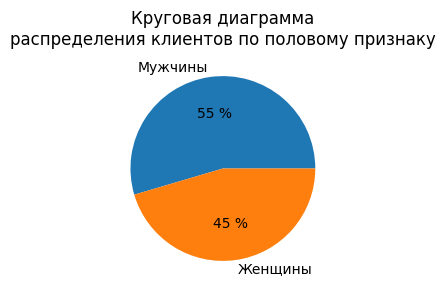

```python
labels = 'Мужчины', 'Женщины'
plt.figure(figsize=(3, 3))
plt.pie(data['gender'].value_counts(), labels=labels, autopct='%.0f %%')
plt.title('Круговая диаграмма\nраспределения клиентов по половому признаку')
plt.show()
```

```python
pd.DataFrame(data['gender'].value_counts()).T.rename(
    columns={'male': 'Мужчины', 'female': 'Женщины'},
    index={'gender': 'Кол-во клиентов'})
```

|  | Мужчины | Женщины |
| --- | --- | --- |
| Кол-во клиентов | 5457 | 4543 |

- Значения определены для всех записей.
- Мода — мужчины, её частота — 5457.
- 5457 клиентов (55 %) являются лицами мужского пола, 4543 клиентов (45 %) являются лицами женского пола.
- Количество мужчин к количеству женщин относится как 6 : 5 (отношение близко к отношению 1 : 1, однако мужчин на 20 % больше, чем женщин).

#### Возраст

```python
descriptive_statistics(data['age'], 'Возраст клиентов, лет')
```

|  | Возраст клиентов, лет |
| --- | --- |
| кол-во значений | 10000 |
| кол-во уникальных | 70 |
| мин. | 18 |
| -1.5IQR | 19.0 |
| 25 % | 32.0 |
| мода | [37] |
| медиана | 37.0 |
| среднее ариф. | 38.92 |
| 75 % | 44.0 |
| +1.5IQR | 55.0 |
| макс. | 92 |
| размах | 74 |
| межквартильный размах | 12.0 |

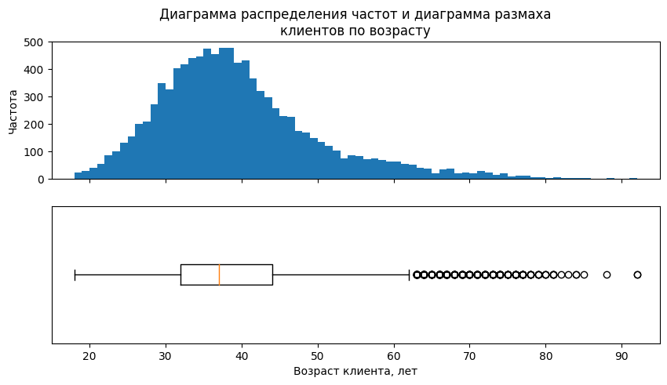

```python
fig, (ax1, ax2) = plt.subplots(2, 1, figsize=(10, 5))
ax1.set_title('Диаграмма распределения частот и диаграмма размаха' +
              '\nклиентов по возрасту')
ax1.hist(data['age'], bins=[n for n in range(93)])
ax1.set_xlim(15, 95)
ax1.tick_params(labelbottom=False)
ax1.set_ylabel('Частота')
ax2.boxplot(data['age'], vert=False)
ax2.set_xlim(15, 95)
ax2.tick_params(left=False, labelleft=False)
ax2.set_xlabel('Возраст клиента, лет')
plt.show()
```

#### Страна проживания

```python
pd.DataFrame(data['geography'].describe()).rename(
    index={'count': 'кол-во значений',
           'unique': 'кол-во уникальных',
           'top': 'мода',
           'freq': 'частота моды'},
    columns={'geography': 'Страна проживания'})
```

|  | Страна проживания |
| --- | --- |
| кол-во значений | 10000 |
| кол-во уникальных | 3 |
| мода | france |
| частота моды | 5014 |

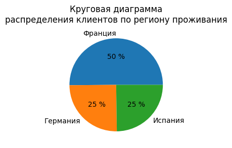

```python
labels = 'Франция', 'Германия', 'Испания'
plt.figure(figsize=(3, 3))
plt.pie(data['geography'].value_counts(), labels=labels, autopct='%.0f %%')
plt.title('Круговая диаграмма\nраспределения клиентов по региону проживания')
plt.show()
```

```python
pd.DataFrame(data['geography'].value_counts()).T.rename(
    index={'geography': 'Количество клиентов в регионе'},
    columns={'france': 'Франция', 'germany': 'Германия', 'spain': 'Испания'})
```

|  | Франция | Германия | Испания |
| --- | --- | --- | --- |
| Количество клиентов в регионе | 5014 | 2509 | 2477 |

#### Предполагаемая зарплата

```python
descriptive_statistics(data['estimated_salary'],
                       'Предполагаемая зарплата, у. е.')
```

|  | Предполагаемая зарплата, у. е. |
| --- | --- |
| кол-во значений | 10000 |
| кол-во уникальных | 9999 |
| мин. | 11.58 |
| -1.5IQR | -47385.29125 |
| 25 % | 51002.11 |
| мода | [24924.92] |
| медиана | 100193.92 |
| среднее ариф. | 100090.24 |
| 75 % | 149388.25 |
| +1.5IQR | 247773.12125 |
| макс. | 199992.48 |
| размах | 199980.9 |
| межквартильный размах | 98386.1375 |

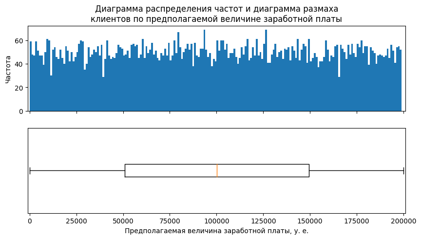

```python
fig, (ax1, ax2) = plt.subplots(2, 1, figsize=(10, 5))
ax1.set_title('Диаграмма распределения частот и диаграмма размаха' +
              '\nклиентов по предполагаемой величине заработной платы')
ax1.hist(data['estimated_salary'], bins=[1000*n for n in range(200)])
ax1.set_xlim(-1000, 201000)
ax1.tick_params(labelbottom=False)
ax1.set_ylabel('Частота')
ax2.boxplot(data['estimated_salary'], vert=False)
ax2.set_xlim(-1000, 201000)
ax2.tick_params(left=False, labelleft=False)
ax2.set_xlabel('Предполагаемая величина заработной платы, у. е.')
plt.show()
```

- Значения определены для всех записей.
- Значения определены с точностью до 0,01.
- Для 10 000 записей встречается 9999 различных уникальных значений.
- Минимальное значение — 11,58 у. е., максимальное значение — 199 992,48 у. е.
- Медиана — 100 193,92 у. е., среднее арифметическое — 100 090,24 у. е.
- Распределение равномерное.
- Оценённая заработная плата половины всех пользователей составляет 50–150 тыс. у. е.

### Данные об активности клиентов

#### Период обслуживания в банке

```python
descriptive_statistics(data['tenure'],
                       'Период обслуживания в банке, полных лет')
```

|  | Период обслуживания в банке, полных лет |
| --- | --- |
| кол-во значений | 10000 |
| кол-во уникальных | 11 |
| мин. | 0.0 |
| -1.5IQR | -2.5 |
| 25 % | 2.0 |
| мода | [2.0] |
| медиана | 5.0 |
| среднее ариф. | 4.95 |
| 75 % | 7.0 |
| +1.5IQR | 12.5 |
| макс. | 10.0 |
| размах | 10.0 |
| межквартильный размах | 5.0 |

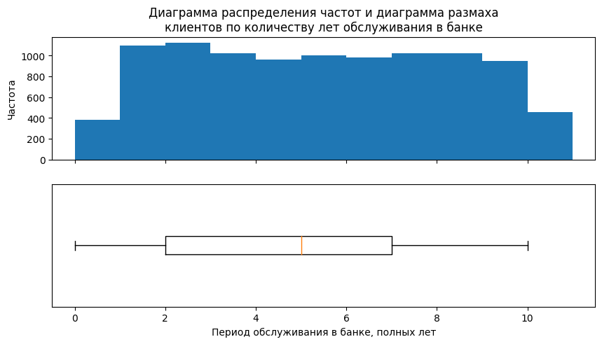

```python
fig, (ax1, ax2) = plt.subplots(2, 1, figsize=(10, 5))
ax1.set_title('Диаграмма распределения частот и диаграмма размаха' +
              '\nклиентов по количеству лет обслуживания в банке')
ax1.hist(data['tenure'], bins=[n for n in range(12)])
ax1.set_xlim(-0.5, 11.5)
ax1.tick_params(labelbottom=False)
ax1.set_ylabel('Частота')
ax2.boxplot(data['tenure'], vert=False)
ax2.set_xlim(-0.5, 11.5)
ax2.tick_params(left=False, labelleft=False)
ax2.set_xlabel('Период обслуживания в банке, полных лет')
plt.show()
```

#### Активность клиента

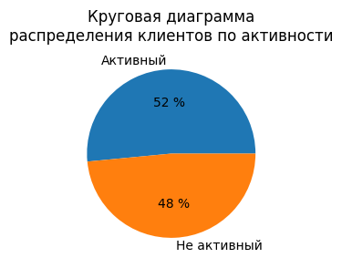

```python
labels = 'Активный', 'Не активный'
plt.figure(figsize=(3, 3))
plt.pie(data['is_active_member'].value_counts(),
        labels=labels, autopct='%.0f %%')
plt.title('Круговая диаграмма\nраспределения клиентов по активности')
plt.show()
```

```python
pd.DataFrame(data['is_active_member'].value_counts()).T.rename(
    columns={1: 'Активный', 0: 'Не активный'},
    index={'is_active_member': 'Кол-во клиентов'})
```

|  | Активный | Не активный |
| --- | --- | --- |
| Кол-во клиентов | 5151 | 4849 |

#### Баланс банковского счёта

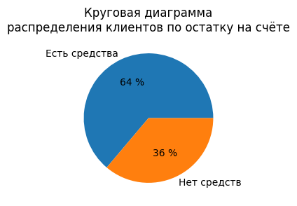

```python
labels = 'Есть средства', 'Нет средств'
plt.figure(figsize=(3, 3))
plt.pie((data['balance'] > 0).value_counts(), labels=labels, autopct='%.0f %%')
plt.title('Круговая диаграмма\nраспределения клиентов по остатку на счёте')
plt.show()
```

```python
pd.DataFrame((data['balance'] > 0).value_counts()).T.rename(
    columns={0: 'Нет средств', 1: 'Есть средства'},
    index={'balance': 'Кол-во клиентов'})
```

|  | Есть средства | Нет средств |
| --- | --- | --- |
| Кол-во клиентов | 6383 | 3617 |

```python
descriptive_statistics(data.loc[data['balance'] > 0, 'balance'],
                       'Баланс банковского счёта, у. е.')
```

|  | Баланс банковского счёта, у. е. |
| --- | --- |
| кол-во значений | 6383 |
| кол-во уникальных | 6381 |
| мин. | 3768.69 |
| -1.5IQR | 60844.2175 |
| 25 % | 100181.98 |
| мода | [105473.74, 130170.82] |
| медиана | 119839.69 |
| среднее ариф. | 119827.49 |
| 75 % | 139512.29 |
| +1.5IQR | 178835.1625 |
| макс. | 250898.09 |
| размах | 247129.4 |
| межквартильный размах | 39330.315 |

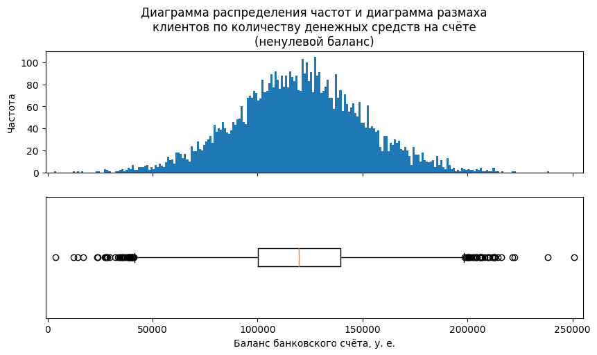

```python
fig, (ax1, ax2) = plt.subplots(2, 1, figsize=(10, 5))
ax1.set_title('Диаграмма распределения частот и диаграмма размаха' +
              '\nклиентов по количеству денежных средств на счёте' +
              '\n(ненулевой баланс)')
ax1.hist(data.loc[data['balance'] > 0, 'balance'],
         bins=[1000*n for n in range(250)])
ax1.set_xlim(-1000, 255000)
ax1.tick_params(labelbottom=False)
ax1.set_ylabel('Частота')
ax2.boxplot(data.loc[data['balance'] > 0, 'balance'], vert=False)
ax2.set_xlim(-1000, 255000)
ax2.tick_params(left=False, labelleft=False)
ax2.set_xlabel('Баланс банковского счёта, у. е.')
plt.show()
```

- Значения определены для всех записей.
- Значения определены с точностью до 0,01 у. е.
- 3617 клиентов (36 %) имеют нулевой баланс счёта, 6383 клиентов (64 %) имеют на счёте денежные средства. Соотношение клиентов с нулевым и ненулевым балансом составляет 1 : 2.
- Для 6383 записей с ненулевыми значениями встречается 6381 различное уникальное значение.
- Минимальное значение — 3768,69 у. е., максимальное значение — 250 898,09 у. е.
- Моды — 105 473,74 у. е. и 130 170,82 у. е., медиана — 119 839,69 у. е., среднее арифметическое — 119 827,49 у. е.
- Распределение унимодальное, симметричное.
- Половина всех пользователей имеет на счёте 100–140 тыс. у. е.
- Практически все пользователи имеют на счёте не более 180 тыс. у. е. Большее количество средств на счёте — явление редкое.

#### Количество продуктов банка, используемых клиентом

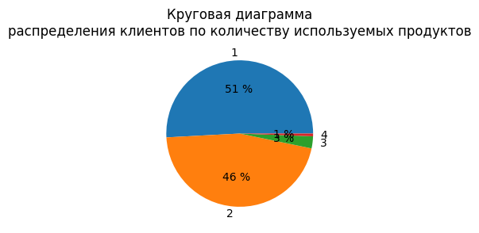

```python
labels = data['num_of_products'].value_counts().index
plt.figure(figsize=(3, 3))
plt.pie(data['num_of_products'].value_counts(),
        labels=labels, autopct='%.0f %%')
plt.title('Круговая диаграмма' +
          '\nраспределения клиентов по количеству используемых продуктов')
plt.show()
```

```python
pd.DataFrame(data['num_of_products'].value_counts()).T.rename(
    index={'num_of_products': 'Кол-во клиентов'})
```

|  | 1 | 2 | 3 | 4 |
| --- | --- | --- | --- | --- |
| Кол-во клиентов | 5084 | 4590 | 266 | 60 |

#### Наличие кредитной карты

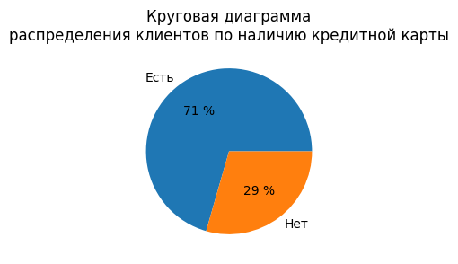

```python
labels = 'Есть', 'Нет'
plt.figure(figsize=(3, 3))
plt.pie(data['has_cr_card'].value_counts(), labels=labels, autopct='%.0f %%')
plt.title('Круговая диаграмма' +
          '\nраспределения клиентов по наличию кредитной карты')
plt.show()
```

```python
pd.DataFrame(data['has_cr_card'].value_counts()).T.rename(
    columns={1: 'Есть кредитная карта', 0: 'Нет кредитной карты'},
    index={'has_cr_card': 'Кол-во клиентов'})
```

|  | Есть кредитная карта | Нет кредитной карты |
| --- | --- | --- |
| Кол-во клиентов | 7055 | 2945 |

- Значения определены для всех записей.
- Мода — кредитная карта есть, её частота — 7055.
- 7055 клиентов (71 %) используют кредитную карту, 2945 клиентов (29 %) не пользуются кредитными картами.
- Количество клиентов, использующих кредитную карту, относится к количеству клиентов, не имеющих кредитную карту, как 2 : 1.

#### Кредитный рейтинг

```python
descriptive_statistics(data['credit_score'], 'Кредитный рейтинг')
```

|  | Кредитный рейтинг |
| --- | --- |
| кол-во значений | 10000 |
| кол-во уникальных | 460 |
| мин. | 350 |
| -1.5IQR | 451.0 |
| 25 % | 584.0 |
| мода | [850] |
| медиана | 652.0 |
| среднее ариф. | 650.53 |
| 75 % | 718.0 |
| +1.5IQR | 853.0 |
| макс. | 850 |
| размах | 500 |
| межквартильный размах | 134.0 |

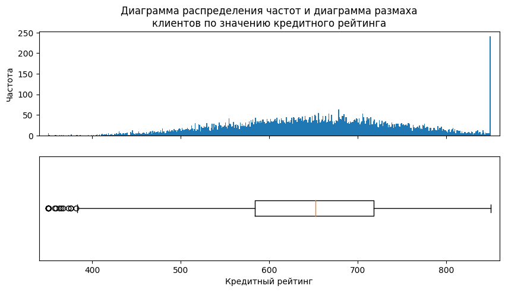

```python
fig, (ax1, ax2) = plt.subplots(2, 1, figsize=(10, 5))
ax1.set_title('Диаграмма распределения частот и диаграмма размаха' +
              '\nклиентов по значению кредитного рейтинга')
ax1.hist(data['credit_score'], bins=[n+350 for n in range(501)])
ax1.set_xlim(340, 860)
ax1.tick_params(labelbottom=False)
ax1.set_ylabel('Частота')
ax2.boxplot(data['credit_score'], vert=False)
ax2.set_xlim(340, 860)
ax2.tick_params(left=False, labelleft=False)
ax2.set_xlabel('Кредитный рейтинг')
plt.show()
```

- Значения определены для всех записей.
- Значения определены с точностью до 1.
- Для 10 000 записей встречается 460 различных уникальных значений.
- Минимальное значение — 350, максимальное значение — 850.
- Мода — 850, медиана — 652.
- Распределение унимодальное, симметричное. Наблюдается резко отличающееся значение частоты для значения рейтинга 850. Вероятно, это значение является граничным (максимальным) и присваивается клиенту при заключении договора с банком; затем, в случае просрочек оплат по кредитам, рейтинг падает.
- Половина всех пользователей имеет кредитный рейтинг 584–718.
- Практически все пользователи имеют рейтинг не менее 450. Меньшее значение рейтинга — явление редкое.

#### Факт ухода клиента из банка

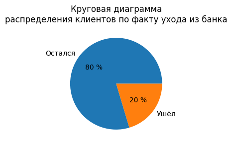

```python
labels = 'Остался', 'Ушёл'
plt.figure(figsize=(3, 3))
plt.pie(data['exited'].value_counts(), labels=labels, autopct='%.0f %%')
plt.title('Круговая диаграмма\nраспределения клиентов по факту ухода из банка')
plt.show()
```

```python
pd.DataFrame(data['exited'].value_counts()).T.rename(
    columns={0: 'Остались', 1: 'Ушли'},
    index={'exited': 'Кол-во клиентов'})
```

|  | Остались | Ушли |
| --- | --- | --- |
| Кол-во клиентов | 7963 | 2037 |

- Значения определены для всех записей.
- Мода — клиент остался в банке, её частота — 7963.
- 7963 клиентов (80 %) продолжают обслуживаться банком, 2037 клиентов (20 %) ушли из банка.
- Количество клиентов, продолжающих обслуживание, относится к количеству клиентов, ушедших из банка, как 4 : 1.

## Построение моделей

### Подготовка данных для обучения

#### Удаление лишних признаков

Значения признака `row_number` являются уникальными, дублируют (со смещением на единицу) значения индексов датафрейма и не несут особой смысловой нагрузки.  
Значения признака `customer_id` встречаются в наборе данных по одному разу, все являются уникальными. Признак является категориальным и может быть заменён без потери смысла на любую упорядоченную последовательность значений, например на значения индексов строк.  
Эти значения не являются важными для обучения модели, более того, будет ошибочным использовать их для обучения.

Признак `surname` тоже не следует использовать для обучения модели. Было бы странно полагать, что факт ухода клиента из банка зависит от фамилии. Использование этого признака для обучения может расцениваться как дискриминация, и поэтому неуместно.

Удалим признаки `row_number`, `customer_id`, `surname` из набора данных.

```python
data.drop(['row_number', 'customer_id', 'surname'], axis=1, inplace=True)
data.columns.sort_values().tolist()
```

```
['age',
 'balance',
 'credit_score',
 'estimated_salary',
 'exited',
 'gender',
 'geography',
 'has_cr_card',
 'is_active_member',
 'num_of_products',
 'tenure']
```

#### Кодирование значений признаков

Поскольку алгоритмы обучения принимают на вход числовые данные, выполним кодирование бинарного признака `gender` значениями *0* и *1*.

```python
data['gender'].replace({'female': 0, 'male': 1}, inplace=True)
data['gender'].unique()
```

```
array([0, 1])
```

Признак `geography` содержит категориальные значения, и их всего три. Уместным будет выполнить кодирование с помощью техники One-Hot Encoding. Чтобы не попасть в дамми-ловушку и избежать наличия избыточных дамми-признаков, удалим один из признаков.

```python
data = pd.get_dummies(data, columns=['geography'], drop_first=True)
data.head()
```

|  | credit_score | gender | age | tenure | balance | num_of_products | has_cr_card | is_active_member | estimated_salary | exited | geography_germany | geography_spain |
| --- | --- | --- | --- | --- | --- | --- | --- | --- | --- | --- | --- | --- |
| 0 | 619 | 0 | 42 | 2.0 | 0.00 | 1 | 1 | 1 | 101348.88 | 1 | 0 | 0 |
| 1 | 608 | 0 | 41 | 1.0 | 83807.86 | 1 | 0 | 1 | 112542.58 | 0 | 0 | 1 |
| 2 | 502 | 0 | 42 | 8.0 | 159660.80 | 3 | 1 | 0 | 113931.57 | 1 | 0 | 0 |
| 3 | 699 | 0 | 39 | 1.0 | 0.00 | 2 | 0 | 0 | 93826.63 | 0 | 0 | 0 |
| 4 | 850 | 0 | 43 | 2.0 | 125510.82 | 1 | 1 | 1 | 79084.10 | 0 | 0 | 1 |

#### Разделение данных на выборки

Выделим из данных целевой признак `exited`.

```python
features = data.drop(['exited'], axis=1)
target = data['exited']
```

Поскольку отдельной тестовой выборки нет, разделим данные на тренировочную, валидационную и тестовую выборки в отношении 3 : 1 : 1. Таким образом, размеры валидационной и тестовой выборок будут равными.

```python
features_other, features_test, target_other, target_test = train_test_split(
    features, target, test_size=0.2, random_state=RANDOM_STATE)
features_train, features_valid, target_train, target_valid = train_test_split(
    features_other, target_other, test_size=0.25, random_state=RANDOM_STATE)
```

Посмотрим, какие выборки получились после разделения.

```python
features_train.shape
```

```
(6000, 11)
```

```python
features_valid.shape
```

```
(2000, 11)
```

```python
features_test.shape
```

```
(2000, 11)
```

#### Масштабирование признаков

У каждого количественного признака различный порядок величин. Чтобы для алгоритмов все признаки имели одинаковую значимость, выполним процедуру масштабирования значений признаков.

```python
columns = ['credit_score', 'age', 'tenure',
           'balance', 'num_of_products', 'estimated_salary']

scaler = StandardScaler()
scaler.fit(features_train[columns])

features_train[columns] = scaler.transform(features_train[columns])
features_valid[columns] = scaler.transform(features_valid[columns])
features_test[columns] = scaler.transform(features_test[columns])
```

```python
pd.concat([features_train, features_valid, features_test]).head()
```

|  | credit_score | gender | age | tenure | balance | num_of_products | has_cr_card | is_active_member | estimated_salary | geography_germany | geography_spain |
| --- | --- | --- | --- | --- | --- | --- | --- | --- | --- | --- | --- |
| 4495 | 1.427934 | 0 | -0.656100 | 0.713387 | -0.113714 | -0.905397 | 1 | 0 | 0.134255 | 0 | 0 |
| 6470 | -0.705851 | 0 | 0.198238 | 0.015357 | 0.018224 | -0.905397 | 1 | 0 | 1.572963 | 1 | 0 |
| 2221 | 1.200054 | 0 | -0.371320 | 0.364372 | 0.894255 | -0.905397 | 1 | 0 | 0.274208 | 1 | 0 |
| 7686 | 0.692503 | 1 | 0.862723 | 1.411418 | -1.227467 | 0.805051 | 1 | 1 | -0.479772 | 0 | 0 |
| 9419 | 0.361041 | 1 | -1.225658 | -1.380704 | -0.306243 | -0.905397 | 1 | 1 | -0.356880 | 1 | 0 |

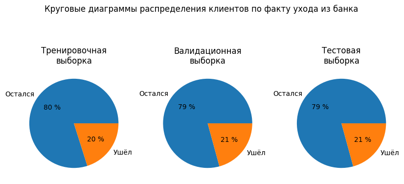

```python
labels = 'Остался', 'Ушёл'
fig, (ax1, ax2, ax3) = plt.subplots(1, 3, figsize=(10, 5))
ax1.pie(target_train.value_counts(), labels=labels, autopct='%.0f %%')
ax1.set_title('Тренировочная\nвыборка')
ax2.pie(target_valid.value_counts(), labels=labels, autopct='%.0f %%')
ax2.set_title('Валидационная\nвыборка')
ax3.pie(target_test.value_counts(), labels=labels, autopct='%.0f %%')
ax3.set_title('Тестовая\nвыборка')
fig.suptitle('Круговые диаграммы распределения клиентов по факту ухода из банка')
plt.show()
```

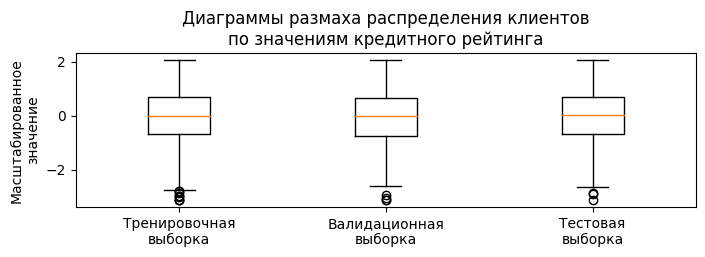

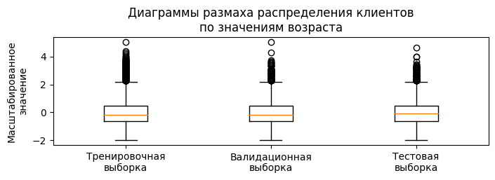

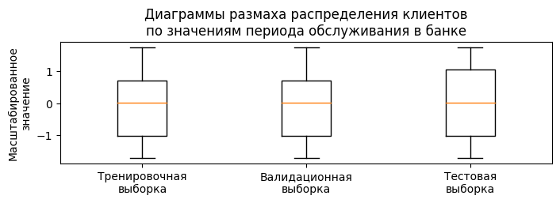

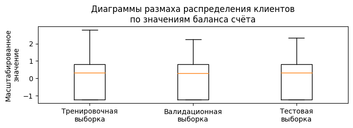

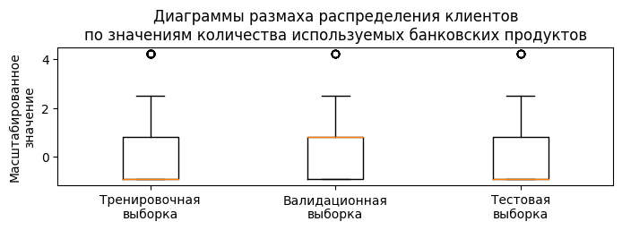

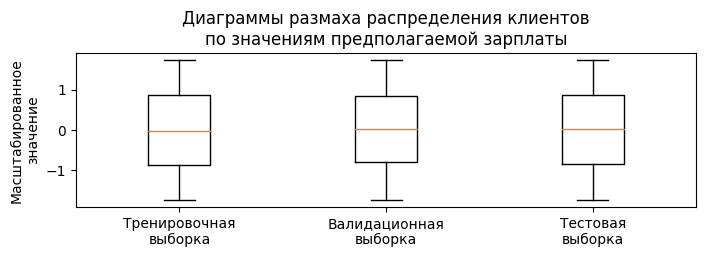

```python
for column_name in ['credit_score', 'age', 'tenure',
                    'balance', 'num_of_products', 'estimated_salary']:
    title_rename = {'credit_score': 'кредитного рейтинга',
                    'age': 'возраста',
                    'tenure': 'периода обслуживания в банке',
                    'balance': 'баланса счёта',
                    'num_of_products': 'количества используемых банковских продуктов',
                    'estimated_salary': 'предполагаемой зарплаты'}
    plt.figure(figsize=(8, 2))
    plt.boxplot([
        features_train[column_name],
        features_valid[column_name],
        features_test[column_name],
    ])
    plt.title('Диаграммы размаха распределения клиентов' +
              f'\nпо значениям {title_rename[column_name]}')
    plt.xticks([1, 2, 3], ['Тренировочная\nвыборка', 'Валидационная\nвыборка',
                           'Тестовая\nвыборка'])
    plt.ylabel('Масштабированное\nзначение')
    plt.show()
```

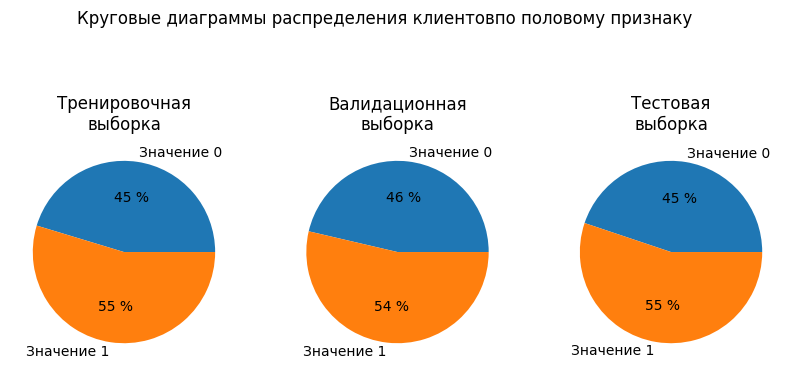

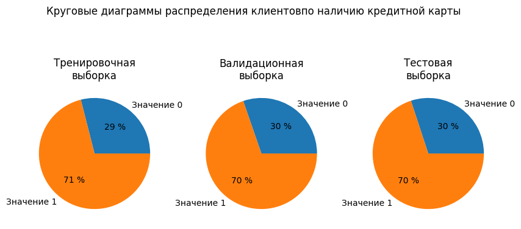

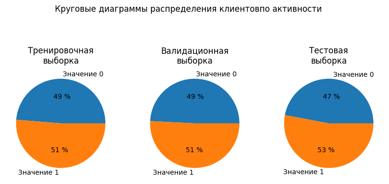

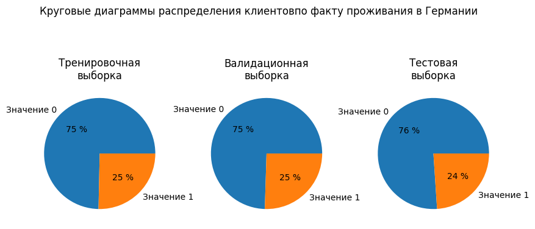

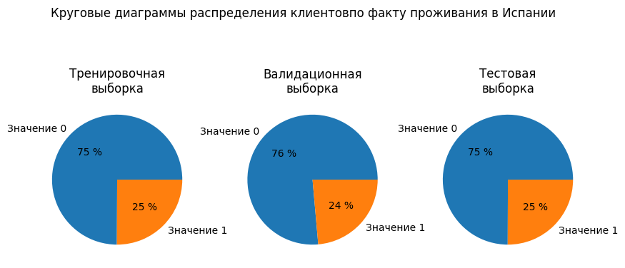

```python
for column_name in ['gender', 'has_cr_card', 'is_active_member',
                    'geography_germany', 'geography_spain']:
    title_rename = {'gender': 'половому признаку',
                    'has_cr_card': 'наличию кредитной карты',
                    'is_active_member': 'активности',
                    'geography_germany': 'факту проживания в Германии',
                    'geography_spain': 'факту проживания в Испании'}

    fig, (ax1, ax2, ax3) = plt.subplots(1, 3, figsize=(10, 5))
    ax1.pie(features_train[column_name].value_counts().sort_index(),
            labels=['Значение 0', 'Значение 1'], autopct='%.0f %%')
    ax1.set_title('Тренировочная\nвыборка')
    ax2.pie(features_valid[column_name].value_counts().sort_index(),
            labels=['Значение 0', 'Значение 1'], autopct='%.0f %%')
    ax2.set_title('Валидационная\nвыборка')
    ax3.pie(features_test[column_name].value_counts().sort_index(),
            labels=['Значение 0', 'Значение 1'], autopct='%.0f %%')
    ax3.set_title('Тестовая\nвыборка')
    fig.suptitle('Круговые диаграммы распределения клиентов' +
                 f'по {title_rename[column_name]}')
    plt.show()
```

- Разделение данных на выборки (тренировочную, валидационную, тестовую) произведено удовлетворительно. Выборки получились репрезентативными. Основные статистические характеристики (например, медиана, межквартильный размах) принимают близкие значения.
- Соотношение клиентов, ушедших из банка и оставшихся, сохранено в каждой выборке приблизительно одинаковым и равным таковому отношению во всём наборе данных — 4 : 1.

### Обучение моделей

Поскольку целевой признак `exited` — категориальный (бинарный), следовательно, необходимо решить задачу бинарной классификации.

Зафиксируем псевдослучайность для алгоритмов обучения.

Оценку качества обученной модели проведём, рассчитав значение F1-меры.

Для того чтобы получить максимально высокое качество предсказания, нужно перебрать в алгоритмах обучения разные значения гиперпараметров: глубины дерева, количества деревьев или количества итераций (в регрессии).

Наилучшими гиперпараметрами для моделей классификации признаем те, при которых получится максимальное значение F1-меры обученной модели, оценённой на валидационной выборке.

Предварительно зададим функцию, рассчитывающую метрики качества моделей.

```python
def metrics(target_train, predictions_train,
            target_valid, predictions_valid, features_valid):
    '''
    Метрики задачи классификации.

    Принимает значения целевого признака из тренировочной и
    валидационной выборок, а также предсказанные значения целевого признака.
    Возвращает DataFrame с основными метриками задачи бинарной классификации.
    '''

    probabilities_valid = model.predict_proba(features_valid)
    probabilities_one_valid = probabilities_valid[:, 1]

    return pd.DataFrame({
        'Метрика модели': ['Правильность', 'Точность', 'Полнота',
                           'F1-мера', 'AUC ROC'],
        'на валидационной выборке' : [
            accuracy_score(target_valid, predictions_valid).round(3),
            precision_score(target_valid, predictions_valid).round(3),
            recall_score(target_valid, predictions_valid).round(3),
            f1_score(target_valid, predictions_valid).round(3),
            roc_auc_score(target_valid, probabilities_one_valid).round(3)
            ],
        'на тренировочной выборке' : [
            accuracy_score(target_train, predictions_train).round(3),
            precision_score(target_train, predictions_train).round(3),
            recall_score(target_train, predictions_train).round(3),
            f1_score(target_train, predictions_train).round(3),
            roc_auc_score(target_valid, probabilities_one_valid).round(3)
            ]
    })
```

#### Решающее дерево

```python
max_tree_depth = 50

best_dtc_model = None
best_dtc_f1 = 0
best_tree_depth = 0

for depth in range(1, max_tree_depth+1):
    model = DecisionTreeClassifier(max_depth=depth,
                                   random_state=RANDOM_STATE)
    model.fit(features_train, target_train)
    predictions_train = model.predict(features_train)
    predictions_valid = model.predict(features_valid)
    f1_valid = f1_score(target_valid, predictions_valid)
    if f1_valid > best_dtc_f1:
        best_dtc_model = model
        best_dtc_f1 = f1_valid
        best_tree_depth = depth

predictions_valid = best_dtc_model.predict(features_valid)
predictions_train = best_dtc_model.predict(features_train)
model = best_dtc_model

print('Модель решающего дерева')
print('Глубина дерева:', best_tree_depth)
metrics(target_train, predictions_train,
        target_valid, predictions_valid, features_valid)
```

```
Модель решающего дерева
Глубина дерева: 7
```

|  | Метрика модели | на валидационной выборке | на тренировочной выборке |
| --- | --- | --- | --- |
| 0 | Правильность | 0.839 | 0.884 |
| 1 | Точность | 0.685 | 0.816 |
| 2 | Полнота | 0.414 | 0.546 |
| 3 | F1-мера | 0.517 | 0.654 |
| 4 | AUC ROC | 0.804 | 0.804 |

#### Случайный лес

```python
max_tree_number = 200
max_tree_depth = 50

best_rfc_model = None
best_rfc_f1 = 0
best_tree_numbers = 0
best_tree_depth = 0

for est in range(10, max_tree_number+1, 10):
    for depth in range(1, max_tree_depth):
        model = RandomForestClassifier(n_estimators=est,
                                       max_depth=depth,
                                       random_state=RANDOM_STATE,
                                       n_jobs=-1)

        model.fit(features_train, target_train)

        predictions_train = model.predict(features_train)
        predictions_valid = model.predict(features_valid)

        f1_valid = f1_score(target_valid, predictions_valid)

        if f1_valid > best_rfc_f1:
            best_rfc_model = model
            best_rfc_f1 = f1_valid
            best_tree_number = est
            best_tree_depth = depth

predictions_valid = best_rfc_model.predict(features_valid)
predictions_train = best_rfc_model.predict(features_train)
model = best_rfc_model

print('Модель случайного леса')
print('Количество деревьев в лесу:', best_tree_number)
print('Глубина каждого дерева:', best_tree_depth)
metrics(target_train, predictions_train,
        target_valid, predictions_valid, features_valid)
```

```
Модель случайного леса
Количество деревьев в лесу: 190
Глубина каждого дерева: 24
```

|  | Метрика модели | на валидационной выборке | на тренировочной выборке |
| --- | --- | --- | --- |
| 0 | Правильность | 0.855 | 1.000 |
| 1 | Точность | 0.766 | 1.000 |
| 2 | Полнота | 0.434 | 1.000 |
| 3 | F1-мера | 0.554 | 1.000 |
| 4 | AUC ROC | 0.838 | 0.838 |

#### Логистическая регрессия

```python
max_iteration_number = 1000

best_lr_model = None
best_lr_f1 = 0
best_lr_iteration_number = 0

for iteration_number in range(100, max_iteration_number+1, 10):
    model = LogisticRegression(max_iter=iteration_number,
                               random_state=RANDOM_STATE,
                               solver='liblinear')

    model.fit(features_train, target_train)

    predictions_train = model.predict(features_train)
    predictions_valid = model.predict(features_valid)

    f1_valid = f1_score(target_valid, predictions_valid)

    if f1_valid > best_lr_f1:
        best_lr_model = model
        best_lr_f1 = f1_valid
        best_lr_iteration_number = iteration_number

predictions_valid = best_lr_model.predict(features_valid)
predictions_train = best_lr_model.predict(features_train)
model = best_lr_model

print('Модель логистической регрессии')
print('Количество итераций:', best_lr_iteration_number)
metrics(target_train, predictions_train,
        target_valid, predictions_valid, features_valid)
```

```
Модель логистической регрессии
Количество итераций: 100
```

|  | Метрика модели | на валидационной выборке | на тренировочной выборке |
| --- | --- | --- | --- |
| 0 | Правильность | 0.808 | 0.814 |
| 1 | Точность | 0.609 | 0.609 |
| 2 | Полнота | 0.202 | 0.204 |
| 3 | F1-мера | 0.304 | 0.305 |
| 4 | AUC ROC | 0.764 | 0.764 |

У всех обученных моделей — решающего дерева, случайного леса, логистической регрессии — наблюдается низкое значение F1-меры. И если точность наилучших моделей превышает значение 0,6, то полнота для всех моделей принимает низкие значения и, таким образом, занижает значение F1-меры.

## Построение моделей с учётом дисбаланса значений в классах

Количество клиентов, продолжающих обслуживание, относится к количеству клиентов, ушедших из банка, как 4 : 1. Возможно, что низкое качество построенных моделей связано с несбалансированностью классов целевого признака.

Чтобы улучшить качество моделей и, следовательно, усилить их предсказательную способность, нужно учесть дисбаланс значений целевого признака.

### Взвешивание классов

#### Решающее дерево

```python
max_tree_depth = 50

best_dtc_model_weighted = None
best_dtc_f1 = 0
best_tree_depth = 0

for depth in range(1, max_tree_depth+1):
    model = DecisionTreeClassifier(max_depth=depth,
                                   random_state=RANDOM_STATE,
                                   class_weight='balanced')

    model.fit(features_train, target_train)

    predictions_train = model.predict(features_train)
    predictions_valid = model.predict(features_valid)

    f1_valid = f1_score(target_valid, predictions_valid)

    if f1_valid > best_dtc_f1:
        best_dtc_model_weighted = model
        best_dtc_f1 = f1_valid
        best_tree_depth = depth

predictions_valid = best_dtc_model_weighted.predict(features_valid)
predictions_train = best_dtc_model_weighted.predict(features_train)
model = best_dtc_model_weighted

print('Модель решающего дерева')
print('Глубина дерева:', best_tree_depth)
metrics(target_train, predictions_train,
        target_valid, predictions_valid, features_valid)
```

```
Модель решающего дерева
Глубина дерева: 8
```

|  | Метрика модели | на валидационной выборке | на тренировочной выборке |
| --- | --- | --- | --- |
| 0 | Правильность | 0.786 | 0.836 |
| 1 | Точность | 0.488 | 0.564 |
| 2 | Полнота | 0.708 | 0.816 |
| 3 | F1-мера | 0.578 | 0.667 |
| 4 | AUC ROC | 0.794 | 0.794 |

#### Случайный лес

```python
max_tree_number = 200
max_tree_depth = 50

best_rfc_model_weighted = None
best_rfc_f1 = 0
best_tree_numbers = 0
best_tree_depth = 0

for est in range(10, max_tree_number+1, 10):
    for depth in range(1, max_tree_depth):
        model = RandomForestClassifier(n_estimators=est,
                                       max_depth=depth,
                                       random_state=RANDOM_STATE,
                                       n_jobs=-1,
                                       class_weight='balanced')

        model.fit(features_train, target_train)

        predictions_train = model.predict(features_train)
        predictions_valid = model.predict(features_valid)

        f1_valid = f1_score(target_valid, predictions_valid)

        if f1_valid > best_rfc_f1:
            best_rfc_model_weighted = model
            best_rfc_f1 = f1_valid
            best_tree_number = est
            best_tree_depth = depth

predictions_valid = best_rfc_model_weighted.predict(features_valid)
predictions_train = best_rfc_model_weighted.predict(features_train)
model = best_rfc_model_weighted

print('Модель случайного леса')
print('Количество деревьев в лесу:', best_tree_number)
print('Глубина каждого дерева:', best_tree_depth)
metrics(target_train, predictions_train,
        target_valid, predictions_valid, features_valid)
```

```
Модель случайного леса
Количество деревьев в лесу: 130
Глубина каждого дерева: 8
```

|  | Метрика модели | на валидационной выборке | на тренировочной выборке |
| --- | --- | --- | --- |
| 0 | Правильность | 0.829 | 0.869 |
| 1 | Точность | 0.575 | 0.643 |
| 2 | Полнота | 0.672 | 0.787 |
| 3 | F1-мера | 0.620 | 0.708 |
| 4 | AUC ROC | 0.845 | 0.845 |

#### Логистическая регрессия

```python
max_iteration_number = 1000

best_lr_model_weighted = None
best_lr_f1 = 0
best_lr_iteration_number = 0

for iteration_number in range(100, max_iteration_number+1, 10):
    model = LogisticRegression(max_iter=iteration_number,
                               random_state=RANDOM_STATE,
                               solver='liblinear',
                               class_weight='balanced')

    model.fit(features_train, target_train)

    predictions_train = model.predict(features_train)
    predictions_valid = model.predict(features_valid)

    f1_valid = f1_score(target_valid, predictions_valid)

    if f1_valid > best_lr_f1:
        best_lr_model_weighted = model
        best_lr_f1 = f1_valid
        best_lr_iteration_number = iteration_number

predictions_valid = best_lr_model_weighted.predict(features_valid)
predictions_train = best_lr_model_weighted.predict(features_train)
model = best_lr_model_weighted

print('Модель логистической регрессии')
print('Количество итераций:', best_lr_iteration_number)
metrics(target_train, predictions_train,
        target_valid, predictions_valid, features_valid)
```

```
Модель логистической регрессии
Количество итераций: 100
```

|  | Метрика модели | на валидационной выборке | на тренировочной выборке |
| --- | --- | --- | --- |
| 0 | Правильность | 0.709 | 0.710 |
| 1 | Точность | 0.387 | 0.379 |
| 2 | Полнота | 0.689 | 0.693 |
| 3 | F1-мера | 0.496 | 0.490 |
| 4 | AUC ROC | 0.763 | 0.763 |

### Увеличение выборки

```python
def upsample(features, target):
    features_zeros = features[target == 0]
    features_ones = features[target == 1]
    target_zeros = target[target == 0]
    target_ones = target[target == 1]

    repeat = round(len(target_zeros)/len(target_ones))

    features_upsampled = pd.concat([features_zeros] + [features_ones] * repeat)
    target_upsampled = pd.concat([target_zeros] + [target_ones] * repeat)

    features_upsampled, target_upsampled = shuffle(
        features_upsampled, target_upsampled, random_state=12345)

    return features_upsampled, target_upsampled

features_train_upsampled, target_train_upsampled = upsample(
    features_train, target_train)
```

Посмотрим, какие выборки получились (на примере целевого признака).

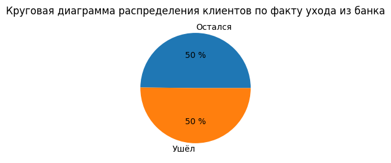

```python
plt.figure(figsize=(3, 3))
plt.pie(target_train_upsampled.value_counts().sort_index(),
        labels = ['Остался', 'Ушёл'], autopct='%.0f %%')
plt.title('Круговая диаграмма распределения клиентов по факту ухода из банка')
plt.show()
```

```python
target_train.shape
```

```
(6000,)
```

```python
target_train_upsampled.shape
```

```
(9621,)
```

#### Решающее дерево

```python
max_tree_depth = 50

best_dtc_model_upsampled = None
best_dtc_f1 = 0
best_tree_depth = 0

for depth in range(1, max_tree_depth+1):
    model = DecisionTreeClassifier(max_depth=depth,
                                   random_state=RANDOM_STATE)

    model.fit(features_train_upsampled, target_train_upsampled)

    predictions_train = model.predict(features_train_upsampled)
    predictions_valid = model.predict(features_valid)

    f1_valid = f1_score(target_valid, predictions_valid)

    if f1_valid > best_dtc_f1:
        best_dtc_model_upsampled = model
        best_dtc_f1 = f1_valid
        best_tree_depth = depth

predictions_valid = best_dtc_model_upsampled.predict(features_valid)
predictions_train = best_dtc_model_upsampled.predict(features_train_upsampled)
model = best_dtc_model_upsampled

print('Модель решающего дерева')
print('Глубина дерева:', best_tree_depth)
metrics(target_train_upsampled, predictions_train,
        target_valid, predictions_valid, features_valid)
```

```
Модель решающего дерева
Глубина дерева: 8
```

|  | Метрика модели | на валидационной выборке | на тренировочной выборке |
| --- | --- | --- | --- |
| 0 | Правильность | 0.786 | 0.829 |
| 1 | Точность | 0.489 | 0.838 |
| 2 | Полнота | 0.711 | 0.816 |
| 3 | F1-мера | 0.580 | 0.827 |
| 4 | AUC ROC | 0.796 | 0.796 |

#### Случайный лес

```python
max_tree_number = 200
max_tree_depth = 50

best_rfc_model_upsampled = None
best_rfc_f1 = 0
best_tree_numbers = 0
best_tree_depth = 0

for est in range(10, max_tree_number+1, 10):
    for depth in range(1, max_tree_depth):
        model = RandomForestClassifier(n_estimators=est,
                                       max_depth=depth,
                                       random_state=RANDOM_STATE,
                                       n_jobs=-1)

        model.fit(features_train_upsampled, target_train_upsampled)

        predictions_train = model.predict(features_train_upsampled)
        predictions_valid = model.predict(features_valid)

        f1_valid = f1_score(target_valid, predictions_valid)

        if f1_valid > best_rfc_f1:
            best_rfc_model_upsampled = model
            best_rfc_f1 = f1_valid
            best_tree_number = est
            best_tree_depth = depth

predictions_valid = best_rfc_model_upsampled.predict(features_valid)
predictions_train = best_rfc_model_upsampled.predict(features_train_upsampled)
model = best_rfc_model_upsampled

print('Модель случайного леса')
print('Количество деревьев в лесу:', best_tree_number)
print('Глубина каждого дерева:', best_tree_depth)
metrics(target_train_upsampled, predictions_train,
        target_valid, predictions_valid, features_valid)
```

```
Модель случайного леса
Количество деревьев в лесу: 120
Глубина каждого дерева: 10
```

|  | Метрика модели | на валидационной выборке | на тренировочной выборке |
| --- | --- | --- | --- |
| 0 | Правильность | 0.831 | 0.909 |
| 1 | Точность | 0.582 | 0.915 |
| 2 | Полнота | 0.655 | 0.901 |
| 3 | F1-мера | 0.617 | 0.908 |
| 4 | AUC ROC | 0.842 | 0.842 |

#### Логистическая регрессия

```python
max_iteration_number = 1000

best_lr_model_upsampled = None
best_lr_f1 = 0
best_lr_iteration_number = 0

for iteration_number in range(100, max_iteration_number+1, 10):
    model = LogisticRegression(max_iter=iteration_number,
                               random_state=RANDOM_STATE,
                               solver='liblinear')

    model.fit(features_train_upsampled, target_train_upsampled)

    predictions_train = model.predict(features_train_upsampled)
    predictions_valid = model.predict(features_valid)

    f1_valid = f1_score(target_valid, predictions_valid)

    if f1_valid > best_lr_f1:
        best_lr_model_upsampled = model
        best_lr_f1 = f1_valid
        best_lr_iteration_number = iteration_number

predictions_valid = best_lr_model_upsampled.predict(features_valid)
predictions_train = best_lr_model_upsampled.predict(features_train_upsampled)
model = best_lr_model_upsampled

print('Модель логистической регрессии')
print('Количество итераций:', best_lr_iteration_number)
metrics(target_train_upsampled, predictions_train,
        target_valid, predictions_valid, features_valid)
```

```
Модель логистической регрессии
Количество итераций: 100
```

|  | Метрика модели | на валидационной выборке | на тренировочной выборке |
| --- | --- | --- | --- |
| 0 | Правильность | 0.708 | 0.703 |
| 1 | Точность | 0.386 | 0.708 |
| 2 | Полнота | 0.689 | 0.696 |
| 3 | F1-мера | 0.495 | 0.702 |
| 4 | AUC ROC | 0.763 | 0.763 |

### Уменьшение выборки

```python
def downsample(features, target):
    features_zeros = features[target == 0]
    features_ones = features[target == 1]
    target_zeros = target[target == 0]
    target_ones = target[target == 1]

    fraction = round(len(target_ones)/len(target_zeros), 2)

    features_downsampled = pd.concat(
        [features_zeros.sample(frac=fraction, random_state=12345)] +
         [features_ones])
    target_downsampled = pd.concat(
        [target_zeros.sample(frac=fraction, random_state=12345)] +
         [target_ones])

    features_downsampled, target_downsampled = shuffle(
        features_downsampled, target_downsampled, random_state=12345)

    return features_downsampled, target_downsampled

features_train_downsampled, target_train_downsampled = downsample(
    features_train, target_train)
```

Посмотрим, какие выборки получились (на примере целевого признака).

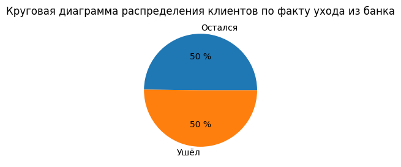

```python
plt.figure(figsize=(3, 3))
plt.pie(target_train_downsampled.value_counts().sort_index(),
        labels = ['Остался', 'Ушёл'], autopct='%.0f %%')
plt.title('Круговая диаграмма распределения клиентов по факту ухода из банка')
plt.show()
```

```python
target_train.shape
```

```
(6000,)
```

```python
target_train_downsampled.shape
```

```
(2405,)
```

#### Решающее дерево

```python
max_tree_depth = 50

best_dtc_model_downsampled = None
best_dtc_f1 = 0
best_tree_depth = 0

for depth in range(1, max_tree_depth+1):
    model = DecisionTreeClassifier(max_depth=depth, random_state=1)
    model.fit(features_train_downsampled, target_train_downsampled)
    predictions_train = model.predict(features_train_downsampled)
    predictions_valid = model.predict(features_valid)
    f1_valid = f1_score(target_valid, predictions_valid)
    if f1_valid > best_dtc_f1:
        best_dtc_model_downsampled = model
        best_dtc_f1 = f1_valid
        best_tree_depth = depth

predictions_valid = best_dtc_model_downsampled.predict(features_valid)
predictions_train = best_dtc_model_downsampled.predict(features_train_downsampled)
model = best_dtc_model_downsampled

print('Модель решающего дерева')
print('Глубина дерева:', best_tree_depth)
metrics(target_train_downsampled, predictions_train,
        target_valid, predictions_valid, features_valid)
```

```
Модель решающего дерева
Глубина дерева: 5
```

|  | Метрика модели | на валидационной выборке | на тренировочной выборке |
| --- | --- | --- | --- |
| 0 | Правильность | 0.797 | 0.770 |
| 1 | Точность | 0.509 | 0.833 |
| 2 | Полнота | 0.617 | 0.677 |
| 3 | F1-мера | 0.558 | 0.747 |
| 4 | AUC ROC | 0.803 | 0.803 |

#### Случайный лес

```python
max_tree_number = 200
max_tree_depth = 50

best_rfc_model_downsampled = None
best_rfc_f1 = 0
best_tree_numbers = 0
best_tree_depth = 0

for est in range(10, max_tree_number+1, 10):
    for depth in range(1, max_tree_depth):
        model = RandomForestClassifier(n_estimators=est,
                                       max_depth=depth,
                                       random_state=RANDOM_STATE,
                                       n_jobs=-1)

        model.fit(features_train_downsampled, target_train_downsampled)

        predictions_train = model.predict(features_train_downsampled)
        predictions_valid = model.predict(features_valid)

        f1_valid = f1_score(target_valid, predictions_valid)

        if f1_valid > best_rfc_f1:
            best_rfc_model_downsampled = model
            best_rfc_f1 = f1_valid
            best_tree_number = est
            best_tree_depth = depth

predictions_valid = best_rfc_model_downsampled.predict(features_valid)
predictions_train = best_rfc_model_downsampled.predict(features_train_downsampled)
model = best_rfc_model_downsampled

print('Модель случайного леса')
print('Количество деревьев в лесу:', best_tree_number)
print('Глубина каждого дерева:', best_tree_depth)
metrics(target_train_downsampled, predictions_train,
        target_valid, predictions_valid, features_valid)
```

```
Модель случайного леса
Количество деревьев в лесу: 200
Глубина каждого дерева: 8
```

|  | Метрика модели | на валидационной выборке | на тренировочной выборке |
| --- | --- | --- | --- |
| 0 | Правильность | 0.806 | 0.874 |
| 1 | Точность | 0.522 | 0.906 |
| 2 | Полнота | 0.737 | 0.836 |
| 3 | F1-мера | 0.611 | 0.869 |
| 4 | AUC ROC | 0.842 | 0.842 |

#### Логистическая регрессия

```python
max_iteration_number = 1000

best_lr_model_downsampled = None
best_lr_f1 = 0
best_lr_iteration_number = 0

for iteration_number in range(100, max_iteration_number+1, 10):
    model = LogisticRegression(max_iter=iteration_number,
                               random_state=RANDOM_STATE,
                               solver='liblinear')

    model.fit(features_train_downsampled, target_train_downsampled)

    predictions_train = model.predict(features_train_downsampled)
    predictions_valid = model.predict(features_valid)

    f1_valid = f1_score(target_valid, predictions_valid)

    if f1_valid > best_lr_f1:
        best_lr_model_downsampled = model
        best_lr_f1 = f1_valid
        best_lr_iteration_number = iteration_number

predictions_valid = best_lr_model_downsampled.predict(features_valid)
predictions_train = best_lr_model_downsampled.predict(features_train_downsampled)
model = best_lr_model_upsampled

print('Модель логистической регрессии')
print('Количество итераций:', best_lr_iteration_number)
metrics(target_train_downsampled, predictions_train,
        target_valid, predictions_valid, features_valid)
```

```
Модель логистической регрессии
Количество итераций: 100
```

|  | Метрика модели | на валидационной выборке | на тренировочной выборке |
| --- | --- | --- | --- |
| 0 | Правильность | 0.704 | 0.707 |
| 1 | Точность | 0.381 | 0.713 |
| 2 | Полнота | 0.684 | 0.695 |
| 3 | F1-мера | 0.489 | 0.704 |
| 4 | AUC ROC | 0.763 | 0.763 |

## Оценка моделей

```python
def test_metrics(target_test, predictions_test, features_test, model):
    '''
    Метрики задачи классификации.

    Принимает значения целевого признака из тестовой выборки,
    а также предсказанные значения целевого признака.
    Возвращает DataFrame с основными метриками задачи бинарной классификации.
    '''

    probabilities_test = model.predict_proba(features_test)
    probabilities_one_test = probabilities_test[:, 1]

    return pd.DataFrame({
        'Метрика модели': ['Правильность', 'Точность', 'Полнота',
                           'F1-мера', 'AUC ROC'],
        'на тестовой выборке' : [
            accuracy_score(target_test, predictions_test).round(3),
            precision_score(target_test, predictions_test).round(3),
            recall_score(target_test, predictions_test).round(3),
            f1_score(target_test, predictions_test).round(3),
            roc_auc_score(target_test, probabilities_one_test).round(3)
            ]
    })
```

```python
predictions_test = best_rfc_model_weighted.predict(features_test)
print('Модель случайного леса')
print('Количество деревьев в лесу: 130')
print('Глубина каждого дерева: 8')
print('Дисбаланс классов: учтён - взвешивание классов')
test_metrics(target_test, predictions_test,
             features_test, best_rfc_model_weighted)
```

```
Модель случайного леса
Количество деревьев в лесу: 130
Глубина каждого дерева: 8
Дисбаланс классов: учтён - взвешивание классов
```

|  | Метрика модели | на тестовой выборке |
| --- | --- | --- |
| 0 | Правильность | 0.836 |
| 1 | Точность | 0.590 |
| 2 | Полнота | 0.684 |
| 3 | F1-мера | 0.634 |
| 4 | AUC ROC | 0.875 |

## Общий вывод

1. Были обучены модели бинарной классификации: решающее дерево, случайный лес, логистическая регрессия.
- Для каждого алгоритма было обучено несколько моделей с различными гиперпараметрами.
- Критерием выбора лучшей модели было максимальное значение F1-меры, достигнутое на валидационной выборке.
- Для каждого алгоритма был учтён дисбаланс классов целевой переменной. Применено несколько способов учёта дисбаланса: взвешивание классов — заданием гиперпараметра, увеличение выборки — дублированием значений редкого класса, уменьшение выборки — отбором значений превалирующего класса.
- F1-мера обученных моделей бинарной классификации (с максимально достигнутым значением F1-меры на валидационной выборке) проверена на тестовой выборке.
- Кроме F1-меры у обученных моделей были оценены другие метрики — правильность, точность, полнота и AUC ROC.
2. Среди обученных моделей **решающего дерева** (табл. 1) лучшими моделями оказались:
- без учёта дисбаланса: с глубиной дерева — 7; максимальное значение F1-меры на валидационной выборке — 0,517;
- со взвешенными классами: с глубиной дерева — 8; максимальное значение F1-меры на валидационной выборке — 0,578;
- с увеличенной выборкой: с глубиной дерева — 8; максимальное значение F1-меры на валидационной выборке — 0,58;
- с уменьшенной выборкой: с глубиной дерева — 5; максимальное значение F1-меры на валидационной выборке — 0,558.

*Таблица 1.* Метрики модели решающего дерева, полученные на валидационной выборке.

| Модель | Правильность | Точность | Полнота | F1-мера | AUC ROC |
| --- | --- | --- | --- | --- | --- |
| **Решающее дерево:** |  |  |  |  |  |
| – без учёта дисбаланса классов | 0,839 | 0,685 | 0,414 | 0,517 | 0,804 |
| – с учётом дисбаланса классов |  |  |  |  |  |
| – – взвешивание классов | 0,786 | 0,488 | 0,708 | 0,578 | 0,794 |
| – – увеличение выборки | 0,786 | 0,489 | 0,711 | 0,580 | 0,796 |
| – – уменьшение выборки | 0,797 | 0,509 | 0,617 | 0,558 | 0,803 |

У моделей с учтённым дисбалансом классов наблюдается небольшое снижение значения правильности (с 0,84 до 0,79), более значительное снижение значения точности (с 0,68 до 0,5) и большой рост значения полноты (с 0,41 до 0,62 — для модели, обученной на уменьшенной выборке, и до 0,71 — для моделей, обученных на увеличенной выборке или со взвешенными классами).  
Можно заключить, что увеличение F1-меры у моделей с учтённым дисбалансом связано с ростом значения полноты.  
Учёт дисбаланса классов позволил увеличить F1-меру на валидационной выборке на $\frac{0,558}{0,517}-1=0,08=8 \%$ и даже на $\frac{0,580}{0,517}-1=0,12=12 \%$.  
Значение AUC ROC не изменяется и составляет порядка 0,79–0,8 и для моделей с неравными классами целевой переменной, и для моделей с учтённым дисбалансом классов.

3. Среди обученных моделей **случайного леса** (табл. 2) лучшими моделями оказались:
- без учёта дисбаланса: с количеством деревьев — 190 и глубиной каждого дерева — 24;  
  максимальное значение F1-меры на валидационной выборке — 0,554;
- со взвешенными классами: с количеством деревьев — 130 и глубиной каждого дерева — 8;  
  максимальное значение F1-меры на валидационной выборке — 0,62;
- с увеличенной выборкой: с количеством деревьев — 120 и глубиной каждого дерева — 10;  
  максимальное значение F1-меры на валидационной выборке — 0,617;
- с уменьшенной выборкой: с количеством деревьев — 200 и глубиной каждого дерева — 8;  
  максимальное значение F1-меры на валидационной выборке — 0,611.

*Таблица 2*. Метрики модели случайного леса, полученные на валидационной выборке.

| Модель | Правильность | Точность | Полнота | F1-мера | AUC ROC |
| --- | --- | --- | --- | --- | --- |
| **Случайный лес:** |  |  |  |  |  |
| – без учёта дисбаланса классов | 0,855 | 0,766 | 0,434 | 0,554 | 0,838 |
| – с учётом дисбаланса классов |  |  |  |  |  |
| – – взвешивание классов | 0,829 | 0,575 | 0,672 | 0,620 | 0,845 |
| – – увеличение выборки | 0,831 | 0,582 | 0,655 | 0,617 | 0,842 |
| – – уменьшение выборки | 0,806 | 0,522 | 0,737 | 0,611 | 0,842 |

У моделей с учтённым дисбалансом классов наблюдается небольшое снижение значения правильности (с 0,85 до 0,81–0,83), более значительное снижение значения точности (с 0,77 до 0,52–0,58) и большой рост значения полноты (с 0,43 до 0,66–0,74).  
Такой разброс значений метрик у моделей с учтённым дисбалансом классов связан с разным значением подобранных параметров моделей — количеством деревьев в лесу и глубиной каждого дерева.  
Можно заключить, что увеличение F1-меры у моделей с учтённым дисбалансом связано с ростом значения полноты.  
Учёт дисбаланса классов позволил увеличить F1-меру на валидационной выборке на $\frac{0,611}{0,554}-1=0,1=10 \%$ и даже на $\frac{0,620}{0,554}-1=0,12=12 \%$.  
Значение AUC ROC не изменяется и составляет порядка 0,84–0,85 и для моделей с неравными классами целевой переменной, и для моделей с учтённым дисбалансом классов.

4. Среди обученных моделей **логистической регрессии** (табл. 3) лучшими моделями оказались:
- без учёта дисбаланса: с количеством итераций — 100;  
  максимальное значение F1-меры на валидационной выборке — 0,304;
- со взвешенными классами: с количеством итераций — 100;  
  максимальное значение F1-меры на валидационной выборке — 0,496;
- с увеличенной выборкой: с количеством итераций — 100;  
  максимальное значение F1-меры на валидационной выборке — 0,495;
- с уменьшенной выборкой: с количеством итераций — 100;  
  максимальное значение F1-меры на валидационной выборке — 0,489.

*Таблица 3.* Метрики модели логистической регрессии, полученные на валидационной выборке

| Модель | Правильность | Точность | Полнота | F1-мера | AUC ROC |
| --- | --- | --- | --- | --- | --- |
| **Логистическая регрессия:** |  |  |  |  |  |
| – без учёта дисбаланса классов | 0,808 | 0,609 | 0,202 | 0,304 | 0,764 |
| – с учётом дисбаланса классов |  |  |  |  |  |
| – – взвешивание классов | 0,709 | 0,387 | 0,689 | 0,496 | 0,763 |
| – – увеличение выборки | 0,708 | 0,386 | 0,689 | 0,495 | 0,763 |
| – – уменьшение выборки | 0,704 | 0,381 | 0,684 | 0,489 | 0,763 |

У моделей с учтённым дисбалансом классов наблюдается значительное снижение значения правильности (с 0,8 до 0,7), ещё более значительное снижение значения точности (с 0,6 до 0,4) и большой рост значения полноты (с 0,2 до 0,7).  
Можно заключить, что увеличение F1-меры у моделей с учтённым дисбалансом связано с более значительным ростом значения полноты, нежели с уменьшением значения точности.  
Учёт дисбаланса классов позволил увеличить F1-меру на валидационной выборке на $\frac{0,489}{0,304}-1=0,61=61 \%$ и даже на $\frac{0,496}{0,304}-1=0,63=63 \%$.  
Значение AUC ROC не изменяется и составляет порядка 0,76 и для моделей с неравными классами целевой переменной, и для моделей с учтённым дисбалансом классов.

5. Учёт дисбаланса классов целевой переменной позволяет увеличить значение F1-меры на 8–12 % для моделей решающего дерева и случайного леса так, что значение F1-меры у моделей, обученных на данных со сбалансированными классами, будет превышать 0,55 — для модели решающего дерева, и 0,6 — для модели случайного леса. Максимально достигнутое значение F1-меры составляет 0,62.

Учёт дисбаланса приводит к изменению значений точности и полноты обученных моделей. Точность уменьшается, а полнота увеличивается. Увеличение значения полноты "перекрывает" уменьшение значения точности и в итоге приводит к увеличению F1-меры обученных моделей с учтённым дисбалансом по сравнению с моделями, в которых дисбаланс не учтён.

Значение AUC ROC не зависит от соотношения классов целевой переменной и не изменяется для моделей, обученных на данных со сбалансированными классами, по сравнению с моделями, обученными на данных с неравными классами целевой переменной.

Для построения системы, которая спрогнозирует уход клиента из банка рекомендуется использовать обученную со взвешенными классами модель случайного леса с количеством деревьев 130 и максимальной глубиной одного дерева 8. Значение F1-меры для этой модели на тестовой выборке составляет 0,634.